# MT5767 Group Assignment 1

Student ID: 200015016

## 0.1 Section 3

# 1 Part 1

a.) When K is modelled as a function of the current year’s rainfall (scenario 1), the value of Beta 1 is equal to 1.04 whereas when K is modelled as a function of the previous year’s rainfall (scenario 2), this number falls to -0.0286 (See Table 1.1). In order to find the real effect of Beta 1 on carrying capacity, we have to take it’s exponent. When we do that for scenario 1, we see that for every unit increase in rainfall, carrying capacity by a factor of roughly 2.83. In scenario 2 we see that carrying capacity shrinks by a factor of roughly 0.98 for every unit increase in rainfall. The scale of the effect of rainfall in scenario 2 (that is rainfall from the previous year) appears much reduced compared to scenario 1. In the context of this study, it means that, based on our observations, changes in observed population numbers of wildebeest are not reflected as much in changes in the previous years rainfall compared to the current years rainfall.

Table 1.1: Beta1 values and values for population models under different scenarios

| Model | beta_1 |
| --- | --- |
| K = fn(Rt) | 1.0447498 |
| K = fn(Rt-1) | -0.0286159 |

b.) Comparison of AIC values for models generated for the two scenarios show us that modelling carrying capacity as a function of rainfall in the current year appears fits the data better than modelling it as a function of the previous year’s rainfall (Scenario 1 AIC: -19.99; Scenario 2 AIC: -17.08; See Table 2.2 for exact values).

# 2 Part 2

a.) When intrinsic growth rate (rt) is modelled as a function of rainfall in the current year alpha 1 roughly equals 0.63 and when it is modelled as a function of rainfall in the previous year it equals 0.16 (See Table 2.1 for exact values). Unlike carrying capacity, for both scenarios, increases in a 1 unit of rainfall result in increases in intrinsic growth rate. However, under the first modelling scenario, growth rate increases by a factor of 1.88 for every unit increase in rainfall whereas under the second modelling scenario this increase is reduced to a factor of 1.17. As with carrying capacity, we see that when growth rate is modelled as a function of the previous years rainfall, population change is much less sensitive to changes in rainfall.

Table 2.1: Alpha 1 values for population models under different scenarios

| Model | alpha_1 |
| --- | --- |
| r = fn(Rt) | 0.6320499 |
| r = fn(Rt-1) | 0.1560956 |

b.) AIC values for the two models with variable growth rate show us that the model considering growth rate as a function of rainfall this year fits the data better than the other model. The AIC value for the former model is -18.97 compared to -17.15 for the latter (See 2.2 for exact values).

Table 2.2: AIC values and dAIC values for population models under different scenarios

| Model | AIC | dAIC |
| --- | --- | --- |
| K = fn(Rt-1) | -17.08316 | 2.903462 |
| K = fn(Rt) | -19.98662 | 0.000000 |
| r = fn(Rt) | -18.96683 | 1.019796 |
| r = fn(Rt-1) | -17.14583 | 2.840797 |

# 3 Visualising how the models fit our data

From Figure 3.1 we can visualise the outputs for alpha a and beta 1 from the respective models. The models that factor r and K in as a function of rainfall in previous years predict populations to have fluctuated much less compared to the models that factor in r and K as a function of rainfall in the same year. This is probably due to the fact that rainfall in the previous year is not correlated as strongly with observed population in our dataset.

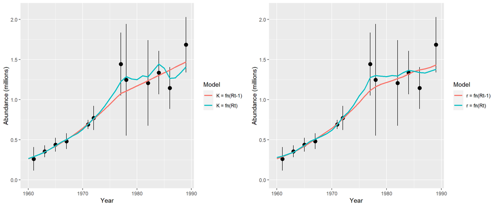

Figure 3.1: Estimated Wildebeest population (millions with 95% CI) from 1960 to 1989. Left: Regression lines from models where carrying capacity is modelled as a function of rainfall from the current year or previous year and intrinsic growth rate is held constant. Right: Regression lines from models where intrinsic growth rate is modelled as a function of rainfall from the current year or previous year and carrying capacity is held constant.